# Midwest AMD Symposium

Bioinformatic Tool Selection Excerise: Testing Viral Genome Assemblers

Author

Affiliation

Jared Johnson

Washington State Public Health Laboratory

# Background

Your lab is validating an Influenza A genome assembly workflow using a hybrid capture panel. Assemblies from this workflow will be used by Molecular Epidemiologists for routine genomic surveillance of influenza in local communities. It is anticipated that up to 200 samples could be submitted for sequencing during peak influenza season. The epidemiologists have requested that genome assemblies be at least 80% complete and 99.5% accurate, to facilitate reliable phylogenetic reconstruction. **You have been tasked with identifying a genome assembly tool that can support this work.** Assume you have unlimited compute resources and no IT restrictions.

**Questions**

**Q1. Are you aware of any genome assembly tools that could support this work?**

**Q2. How could you go about finding genome assembly tools?**

# Initial Tool Selection

Being the resourceful bioinformatician you are, you reach out to the `Microbial Bioinfo` Slack community (staph-b-dev.slack.com) to gather recommendations for viral genome assembly tools. You get a near-instant reply from the Senior Group Leader of Viral Computational Genomics at the Broad Institute detailing multiple tools to explore. After hours of sifting through documentation and peer-reviewed publications, you decide to move forward with the `iVar` assembler because it seems like the easiest tool to use. You also decide to include the `IRMA` assembler because you heard someone on a recent TOAST call talk about how they used it for Influenza A.

**Take a look 🔍**

**Take a moment and familiarize yourself with the [iVar](https://github.com/andersen-lab/ivar) and [IRMA](https://wonder.cdc.gov/amd/flu/irma/) documentation.**

# Part 1: Testing the tools with public data

The lab is still working to on-board the new hybrid capture panel and history tells you it could take a while. As such, you begin the hunt for a reasonable test dataset from NCBI. Luck is on your side🍀 - you stumble across a tiled-amplicon dataset that was generated using the Twist Synthetic Influenza H1N1 (2009) RNA control ([source](https://doi.org/10.1128/mbio.01468-23)). This dataset will allow you to calculate the accuracy and completeness of the `ivar` and `IRMA` assemblies by comparing to the published assemblies that were used to create the synthetic controls. Accuracy and completeness will be calculated using a custom [viral-benchmarking tool](https://github.com/DOH-JDJ0303/viral-benchmarking).

Answer the questions below using the provided data:

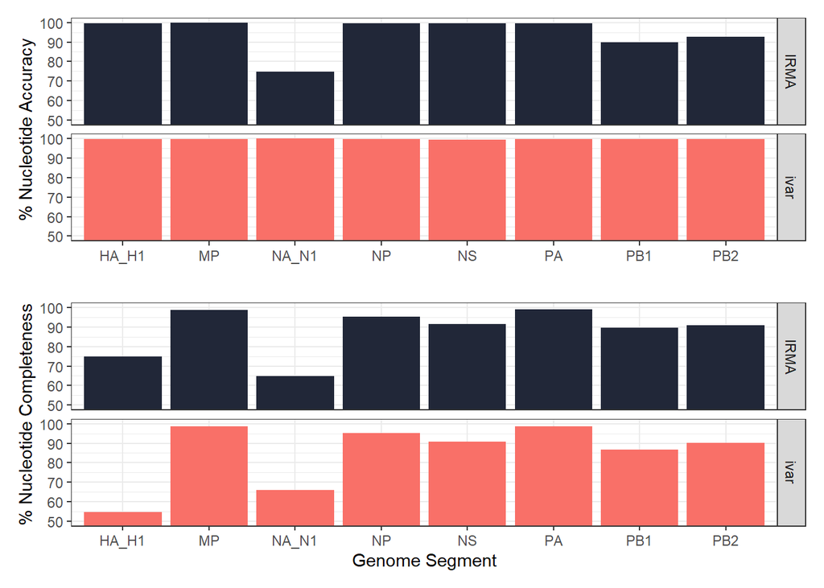

*Figure 1. Bar chart showing the accuracy and completeness of `iVar` and `IRMA` assemblies generated from the H1N1 synthetic control tiled-amplicon data, as compared to the published DNA sequences. Accuracy and completeness are reported separately for each influenza segment.*

**Questions**

**Q1. Which assembler(s) meet(s) the criteria requested by the Molecular Epidemiologists (i.e., 80% completeness and 99.5% accuracy)?**

**Q2. Do you know of any alternative tools that could be used to calculate genome completeness and accuracy? Does your lab have the expertise needed to create a custom script for this purpose, if needed?**

# Part 2: Testing the tools with lab data

Hot diggity dog 🌭 - you just received an email from the lab about new sequence data that was generated using the hybrid capture panel and the same H1N1 synthetic control. While your initial testing indicates `iVar` is the superior tool, you decide to compare both tools again using the new hybrid capture data.

Answer the questions below using the provided data:

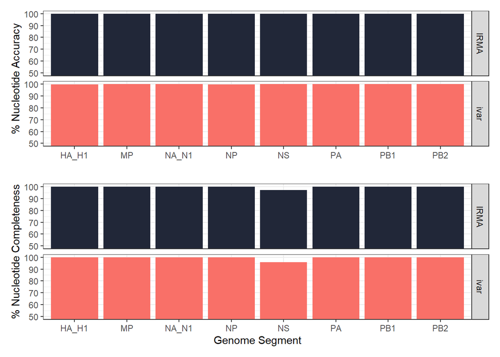

*Figure 2. Bar chart showing the accuracy and completeness of `iVar` and `IRMA` assemblies generated from the H1N1 synthetic control hybrid capture data, as compared to the published DNA sequences. Accuracy and completeness are reported separately for each influenza segment.*

**Take a look 🔍**

Learn about box-and-violin plots [here](https://doh-jdj0303.github.io/binfx-hub/docs/presentations/2025/Midwest_AMD_Symposium/box-violin-example.html)

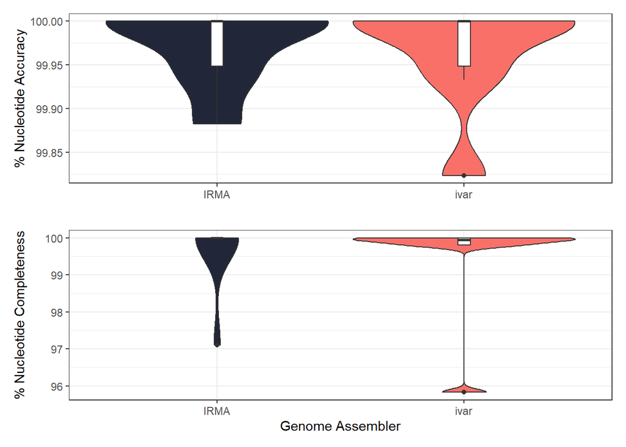

*Figure 3. Box-and-violin plots showing the distribution of assembly accuracy and completeness for `iVar` and `IRMA` assemblies generated from the H1N1 hybrid capture data.*

**Questions**

**Q1. Which assembler(s) meet(s) the criteria requested by the Molecular Epidemiologists (i.e., 80% completeness and 99.5% accuracy)? Does this match your answer from the previous test? If not, why?**

# Part 3: The feature request

All that testing paid off and you were able to validate your genome assembly workflow. While both `IRMA` and `iVar` performed similarly, you decided to use `IRMA` because you think it has a cooler name. The validated workflow has been in use for several months and is considered an all around success 🌟! However, one of the Molecular Epidemiologists recently learned that `IRMA` has a nifty `elongation` feature that can result in more *complete* assemblies. The epi requests that you add this feature to the existing genome assembly workflow, in hopes that it will improve phylogenetic resolution.

You contemplate for a moment simply adding the parameter to the workflow and moving on with your day - whats the worst that could happen 💣? But being the *dedicated*, *quality-focused* bioinformatician you are, you decide to run some additional tests - just in case 🤓.

Answer the questions below using the provided data:

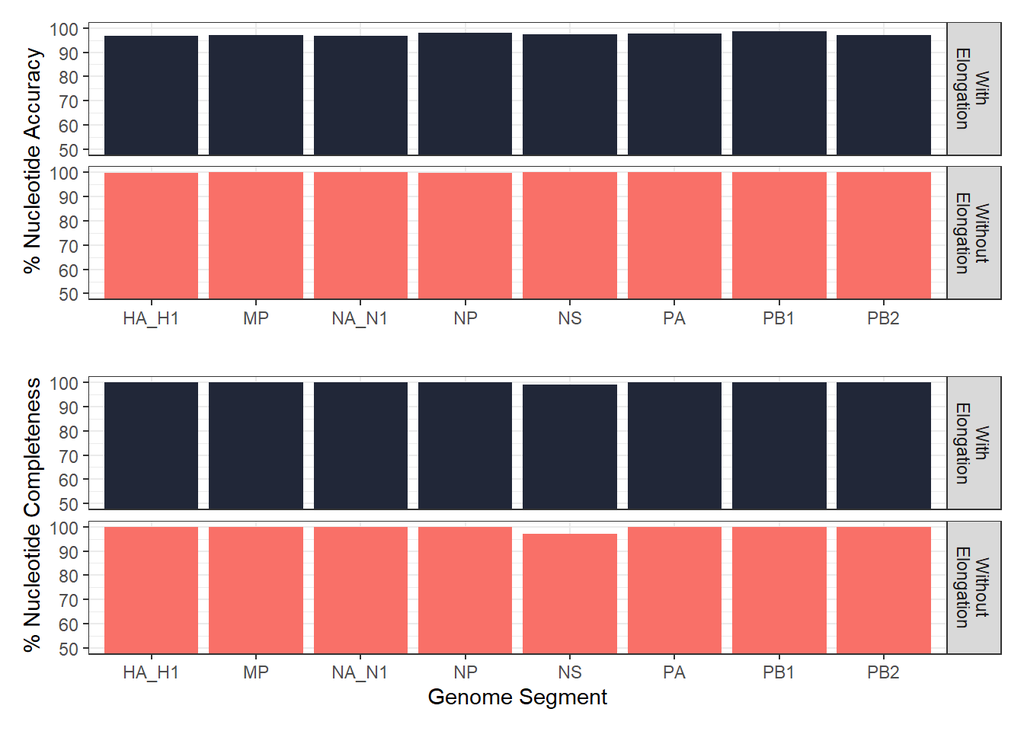

*Figure 4. Bar chart showing the accuracy and completeness of `IRMA` assemblies generated with or without the `elongation` feature from the H1N1 synthetic control hybrid capture data, as compared to the published DNA sequences. Accuracy and completeness are reported separately for each influenza segment.*

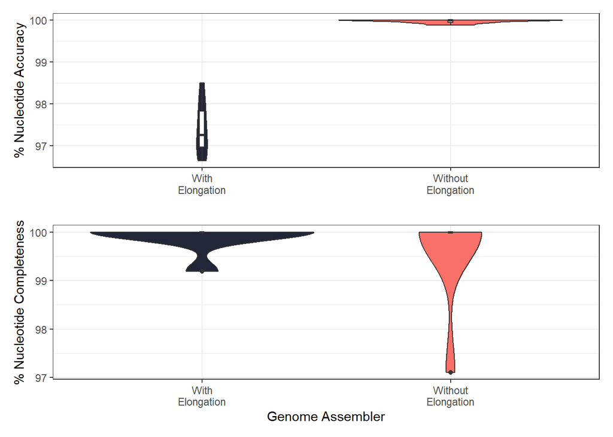

*Figure 3. Box-and-violin plots showing the distribution of assembly accuracy and completeness for `IRMA` assemblies generated with or without the `elongation` feature from the H1N1 hybrid capture data.*

**Questions**

**Q1. Does the `elongation` feature result in more complete assemblies?**

**Q2. Would you use the `elongation` feature based on the supplied data?**